# Random Forest Setup and Tuning

Doug Antibus

2023-12-28

### Defining and tuning a random forest model

In this section we are going to prepare the data for use in a random forest model and attempt to tune parameters to optimize the model fit. After tuning, we will select the best parameters, fit the model on the **training** dataset, then evaluate fit on the **test** dataset.

I choose to use a random forest model for a few reasons:

- random forest is relatively computationally efficient, which will be important given our large dataset
- random forest does not require dummy encoding or one-hot encoding of categorical variables, which will help reduce memory usage
- we can extract variable importance scores from the random forest model. This is important given that our objective is to *understand variables distinguishing members and casuals* rather than to simply make the most accurate model possible.

We will use the `tidymodels` package for model tuning and fitting. The following variables will be used to predict whether trips are taken by members or casual riders.

- start and end station names
- `rideable type` i.e. the type of bike for each trip
- `hod` - hour when trips started
- `dow` - day of the week for trips
- `month` when the trip was taken
- `is_weekend` and `is_holiday` - whether trips are on weekends or holidays, respectively
- whether the trip taken is a `round_trip`

### Data preparation

We’ll read in the most recent dataset and immediately discard rows containing `NA` values. This leaves us with 4.28 million records.

```r
bikes <- read_csv(here("data", "bikes_2.csv")) %>% na.omit()
nrow(bikes) %>% format(big.mark = ",")
```

```
## [1] "4,280,900"
```

The first step is split the data into training and test sets. We will use 70% of the data for training and reserve 30% for testing.

```r
set.seed(123)
split <- initial_split(bikes, prop = 0.7)
train <- training(split)
test <- testing(split)
```

Write the test and train datasets to files if these don’t already exist.

```r
file_exists(here("data", "train.csv"))
```

```
## E:/E_Documents/Coursera/Googe_data_analytics_course/capstone_new/data/train.csv
##                                                                            TRUE
```

```r
if (!file_exists(here("data", "train.csv"))) {
  train %>% write_csv(here("data", "train.csv"))
}

if (!file_exists(here("data", "test.csv"))) {
  test %>% write_csv(here("data", "test.csv"))
}
```

Model tuning will require us to fit and evaluate a total of 100 models (20 parameter combinations for each of 5 cross-validation folds). To allow tuning to go faster, we will take a sub-sample with equal numbers of members and casual riders, with a total size of 200,000 records.

```r
set.seed(123)
spl <- train %>% group_by(member_casual) %>%
  slice_sample(n = 100000) %>%
  ungroup()
nrow(spl)
```

```
## [1] 200000
```

In our dataset, we have many start and end stations which are only represented by one or a few records. This could pose a problem for model tuning: if a station does not appear in the data used to fit a model, we might not be able to make predictions during cross-validation. To address this, we will “lump” start and end station names into an “other” category for names appearing < 100 times in the dataset.

```r
spl <- spl %>%
  mutate(start_name = fct_lump_min(start_name, 100),
         end_name = fct_lump_min(end_name, 100))
```

Next we create a cross-validation object from the sample.

```r
cv <- vfold_cv(spl, v = 5)
```

### Defining a workflow

Define a recipe with predictors as described above and member_casual as the outcome. We specify that `ride_id` is an id variable instead of a predictor.

```r
recipe <- recipe(member_casual ~ ride_id + rideable_type + hod + dow + month + start_name
                 + end_name + is_weekend + is_holiday + round_trip, data = spl) %>%
          update_role(ride_id, new_role = "id variable")
```

Next we define a random forest model, then we place the model and recipe into a workflow object.

The parameters we will tune are:

- `mtry`: the number of randomly chosen predictors used to build trees. It helps to manually set the range for mtry since this depends on the number of predictors in the recipe. One common recommendation is to use mtry equal to the square root of the number of predictors, so we will try bounding mtry between 2 and 7.
- `min_n`: the minimum node size for trees

```r
rf_model <- rand_forest(
  mode = "classification",
  trees = 500,
  mtry = tune(),
  min_n = tune()) %>%
  set_engine("ranger", num.threads = 12, importance = "impurity")

rf_wf <- workflow() %>%
  add_model(rf_model) %>%
  # important that we are using recipe_2, which includes start name and end_name
  add_recipe(recipe)

rf_params <- rf_wf %>% extract_parameter_set_dials()
rf_params <- rf_params %>% update(mtry = mtry(range = c(2, 7)))
```

Finally, we tune the model using 20 parameter combinations. For metrics we track overall accuracy and the area under the ROC curve.

```r
tictoc::tic()
set.seed(123)
rf_res <- tune_grid(rf_wf,
                    resamples = cv,
                    param_info  = rf_params,
                    grid = 20,
                    metrics = metric_set(accuracy, roc_auc),
                    control = control_grid(verbose = TRUE, parallel_over = "resamples")
)
tictoc::toc()

metrics <- rf_res %>% collect_metrics(summarize = TRUE)
metrics %>% write_csv(here("results", "metrics_20grid_200k_records.csv"))
```

### Examining metrics for parameter combinations

```r
metrics <- read_csv(here("results", "metrics_20grid_200k_records.csv")) %>%
  group_by(.metric) %>%
  arrange(desc(mean))
# glimpse(metrics)

metrics %>% mutate(across(c("mean", "std_err"), ~ round(.x, 4))) %>% DT::datatable()
```

|  | mtry | min_n | .metric | .estimator | mean | n | std_err | .config |
| --- | --- | --- | --- | --- | --- | --- | --- | --- |
| 1 | 5 | 40 | roc_auc | binary | 0.6973 | 5 | 0.0008 | Preprocessor1_Model03 |
| 2 | 6 | 38 | roc_auc | binary | 0.6972 | 5 | 0.0006 | Preprocessor1_Model20 |
| 3 | 6 | 35 | roc_auc | binary | 0.697 | 5 | 0.0007 | Preprocessor1_Model02 |
| 4 | 4 | 33 | roc_auc | binary | 0.6967 | 5 | 0.0009 | Preprocessor1_Model01 |
| 5 | 3 | 23 | roc_auc | binary | 0.6955 | 5 | 0.0011 | Preprocessor1_Model11 |
| 6 | 3 | 32 | roc_auc | binary | 0.6953 | 5 | 0.0011 | Preprocessor1_Model05 |
| 7 | 3 | 17 | roc_auc | binary | 0.6951 | 5 | 0.001 | Preprocessor1_Model18 |
| 8 | 3 | 18 | roc_auc | binary | 0.695 | 5 | 0.001 | Preprocessor1_Model08 |
| 9 | 5 | 25 | roc_auc | binary | 0.6946 | 5 | 0.0006 | Preprocessor1_Model07 |
| 10 | 7 | 23 | roc_auc | binary | 0.694 | 5 | 0.0005 | Preprocessor1_Model15 |

[output cut: 30 more lines]

We plot ROC AUC and accuracy over mtry and min_n separately, using open red triangles to visualize the mean for each parameter value. Values of min_n over 35 seem to give the best performance.

The “baseline” accuracy for our model is 0.5, since we sampled equal numbers of member and casual trips. Our tuning accuracy is between 0.62 - 0.64, so the models give some predictive value, although predictions could be better.

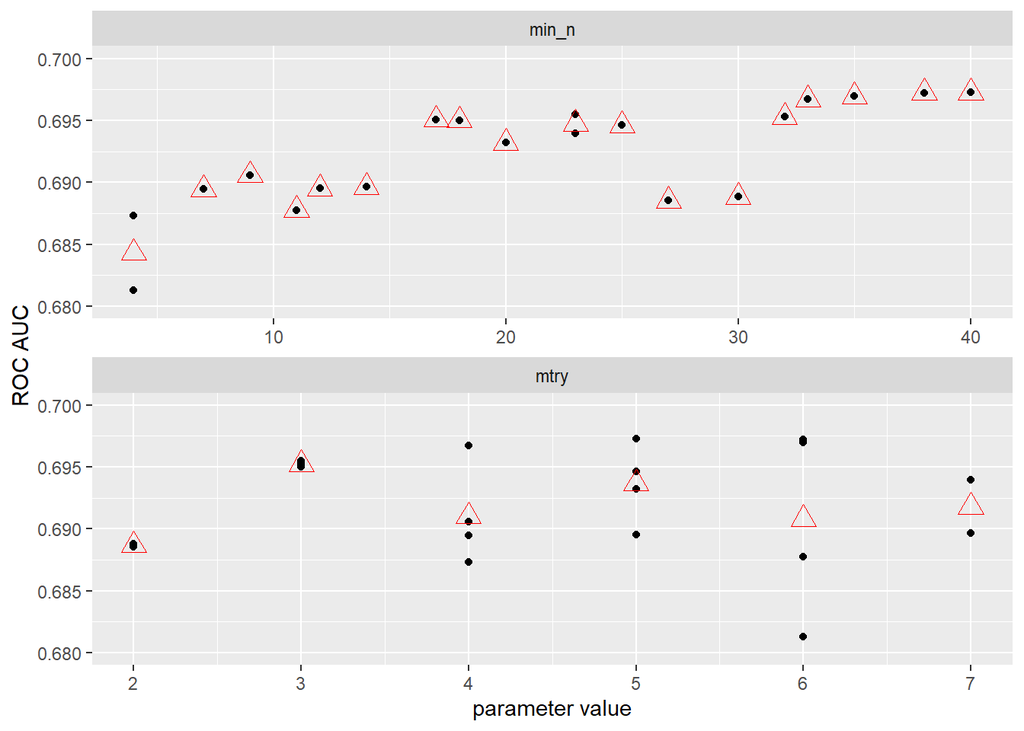

```r
metrics_l <- metrics %>%
  mutate(model = row_number()) %>%
  pivot_longer(mtry:min_n, names_to = "parameter")

metrics_l %>%
  filter(.metric == "roc_auc") %>%
  ggplot(aes(value, mean)) +
  geom_point() +
  facet_wrap(~ parameter, nrow = 2, scales = "free_x") +
  labs(y = "ROC AUC", x = "parameter value") +
  stat_summary(fun = "mean", color = "red", geom = "point", shape = 2, size = 4) +
  scale_y_continuous(limits = c(0.68, 0.7))
```

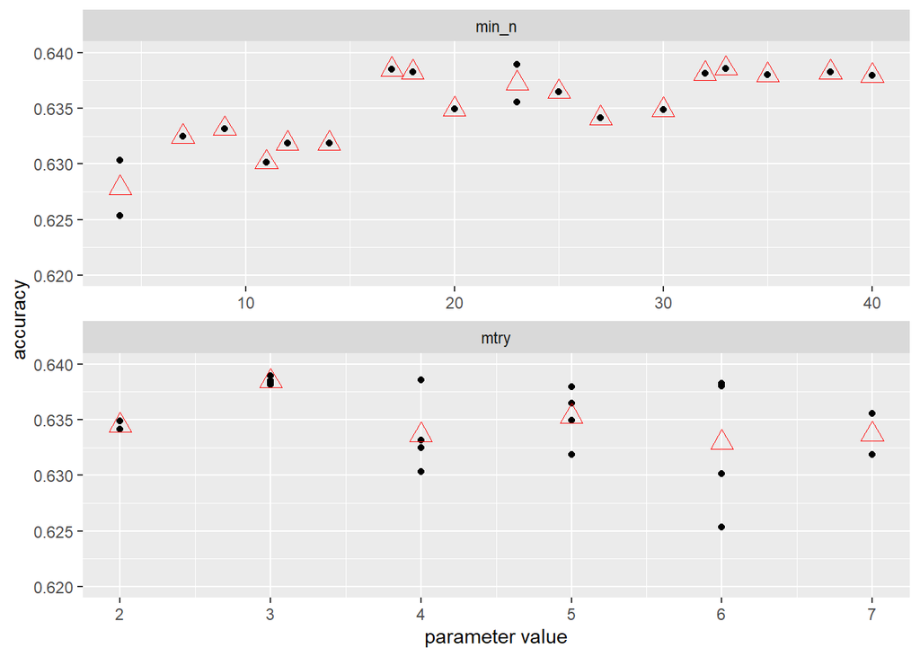

```r
metrics_l %>%
  filter(.metric == "accuracy") %>%
  ggplot(aes(value, mean)) +
  geom_point() +
  facet_wrap(~ parameter, nrow = 2, scales = "free_x") +
  labs(y = "accuracy", x = "parameter value") +
  stat_summary(fun = "mean", color = "red", geom = "point", shape = 2, size = 4) +
  scale_y_continuous(limits = c(0.62, 0.64))
```

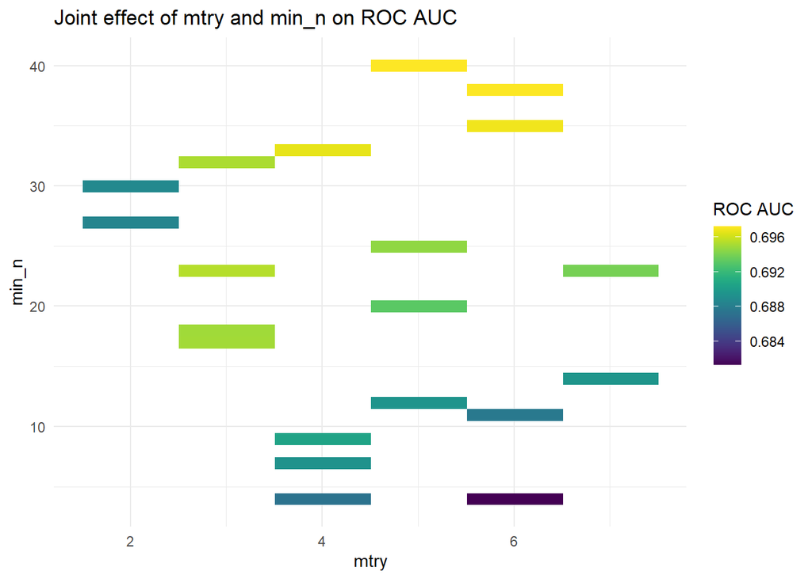

```r
metrics %>%
    filter(.metric == "roc_auc") %>%
    ggplot(aes(mtry, min_n, fill = mean)) +
    geom_raster() +
    scale_fill_viridis() +
  labs(fill = "ROC AUC") +
  theme_minimal() +
  labs(title = "Joint effect of mtry and min_n on ROC AUC")
```